# Reducción de la factorialidad. Análisis de Componentes Principales.

## Análisis Factorial

\[X_1=\alpha_{1 1} F_1+ \alpha_{1 2} F_2+\cdots +\alpha_{1 k} F_k+ E_1+ A_1\] \[X_2=\alpha_{2 1} F_1+ \alpha_{2 2} F_2+\cdots +\alpha_{2 k} F_k+ E_2+ A_2\] \[\cdots\cdots\cdots\cdots\cdots\cdots\cdots\cdots\cdots\cdots\cdots\cdots\] \[X_p=\alpha_{p 1} F_1+ \alpha_{p 2} F_2+\cdots +\alpha_{p k} F_k+ E_p+ A_p\]

## Análisis Factorial

- Podríamos decir que en un Análisis Factorial se fija a priori la cantidad de varianza de cada variableque debe quedar interpretada por los factores comunes.
- Este valor recibe el nombre de comunalidad y se suele representarcomo \(h_i^2\).

Utilizaremos las siguientes notaciones:

- La comunalidad de la variable \(X_i\),\(h_i^2\), es la varianza explicada por \(F_1,F_2,\ldots F_k.\)
- La diferencia \(s_i^2-h_i^2\) es la varianza de la variable \(X_i\) que explican los factores específicos y aleatorios.

\[\color{red}{\mbox{Var. observada = Var. común + Var. específica y aleatorios}}.\]

## El problema de los Componentes Principales

## El problema de los Componentes Principales

\[X_1=\alpha_{1 1} CP_1+ \alpha_{1 2} CP_2+\cdots +\alpha_{1 p} CP_p\] \[X_2=\alpha_{2 1} CP_1+ \alpha_{2 2} CP_2+\cdots +\alpha_{2 p} CP_p\] \[\cdots\cdots\cdots\cdots\cdots\cdots\cdots\cdots\cdots\cdots\cdots\cdots\] \[X_p=\alpha_{p 1} CP_1+ \alpha_{p 2} CP_2+\cdots +\alpha_{p p} CP_p\]

Se trata de encontrar unas nuevas variables \(CP_1,\ldots CP_p\), a las que llamaremos componentes principales, de forma que:

## El problema de los Componentes Principales

- Se cumplan las condiciones anteriores.
- El origen de las variables esté situado en el vector de medias o centro de gravedad de las observaciones.
- Sean incorreladas entre si \(Cor(CP_i,CP_j)=0\) para \(i\not= j, i,j =1,\ldots,p\).
- Se cumple que \(Var(CP_1)\geq Var(CP_2)\geq\cdots\geq Var(CP_p)\) y hagan máximas estas varianzas.
- Se conserva la varianza total (inercia) de la nube de puntos.

## Tipos de A.C.P.

## Tipos de A.C.P:

- Sobre los datos centrados: a cada variable se le resta su media \(x_i-\overline{x}_i\); .
- Sobre los datos tipificados \(\frac{x_{i}-\overline{x}_i}{s_i}\).
- En el primer caso las variables centradas tienen media cero y la misma varianza que las variables originales: se le suele llamar ACP de covarianzas.
- En el segundo caso las variables tipificadas tienen media cero y varianza 1: se le suele llamar ACP de correlaciones o normado.

## Tipos de A.C.P:

Recordemos que dada una matriz de datos \(\mathbf{X}\) (\(n\times p\) es decirde \(n\) individuos y \(p\) variables) representábamos por \(\tilde{\mathbf{X}}\) la matriz de datos centrada. Entonces:

- La matriz de covarianzas de \(\mathbf{X}\) viene dada por

\[\mathbf{S}=1/n \tilde{\mathbf{X}}^t\tilde{\mathbf{X}}\]

- Si llamamos \(\mathbf{Z}\) a la tabla de los datos tipificados, la matriz de correlaciones viene dada por

\[\mathbf{R}=1/n \mathbf{Z}^t\mathbf{Z}\]

## A.C.P: interpretación geométrica

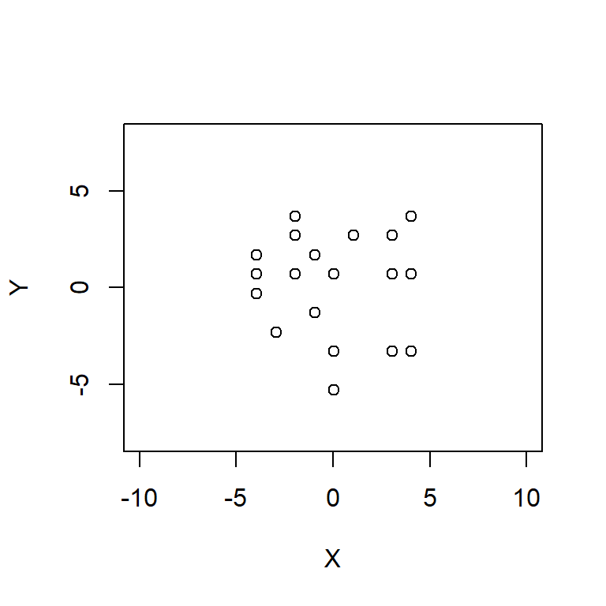

## Interpretación geométrica

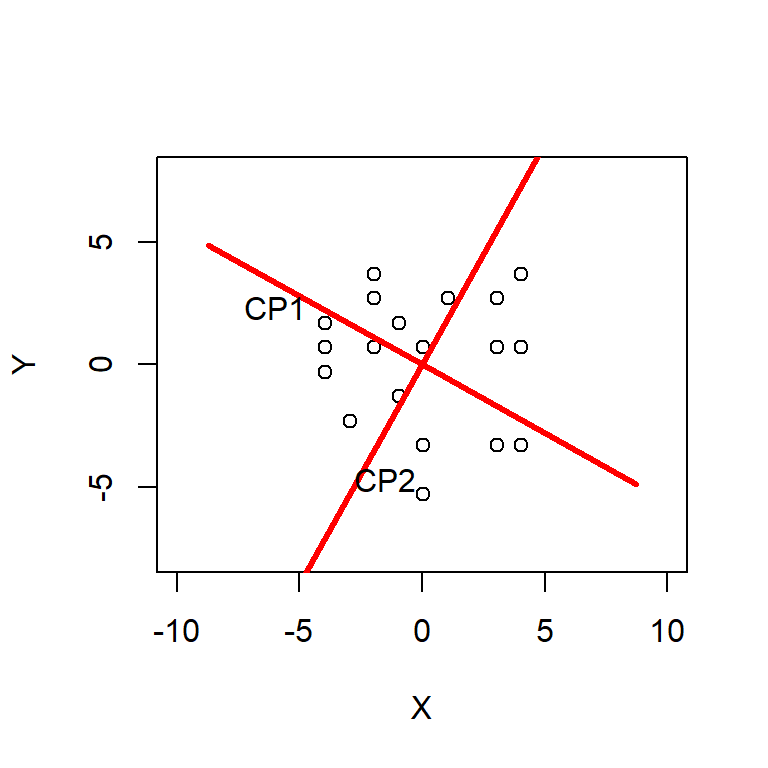

## Interpretación geométrica

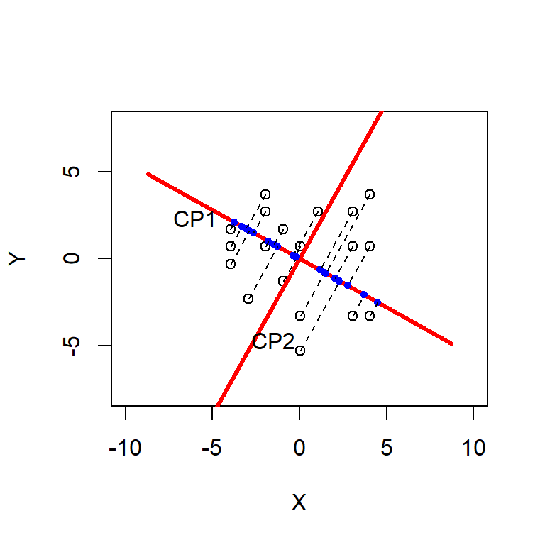

## Interpretación geométrica

Lo que significa que la varianza de los puntos azules es máxima; en el sentido de que sicualquier otra dirección o recta las peoyecciones sobre ésta tendra´n a lo más igual varianza.

Los puntos azules representan las coordenadas que tienen los puntos de nuestra tabla de dartos (centrada) tomando como eje de abcisas el \(CP_1\).

## Interpretación geométrica

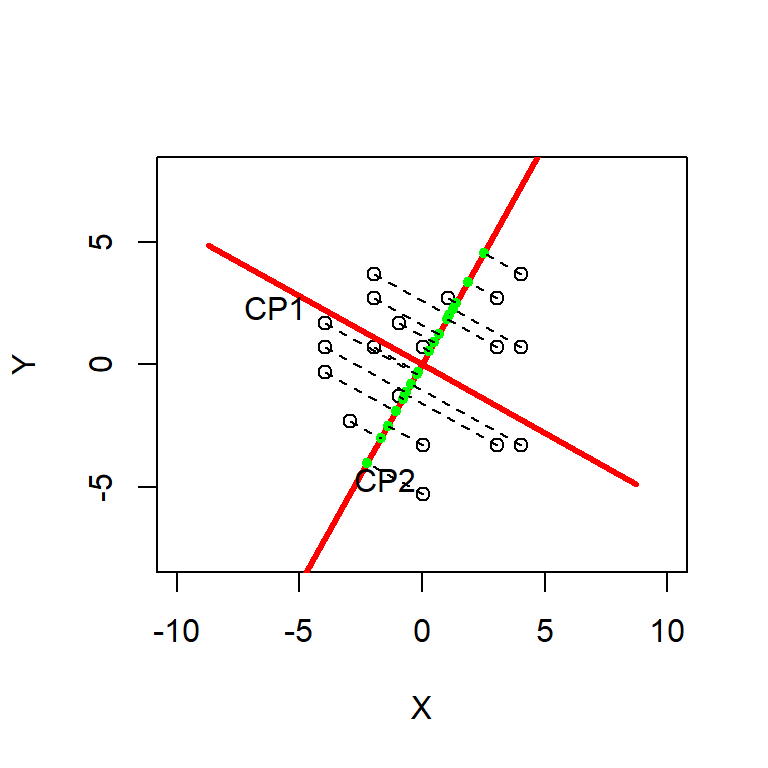

## ACP covarianzas:

## ACP covarianzas:

- Sea \(\mathbf{S}\) la matriz de covarianzas de orden \(p\). Calculamos sus valores propios

\[\lambda_1\geq \lambda_2\geq\ldots\geq\lambda_p\]

y los correspondientes vectores propios ortonormales (perpendiculares y de norma 1)

\[\mathbf{u}_1,\mathbf{u}_2,\ldots,\mathbf{u}_p\]

## Ejemplo

Vamos a realizar un ACP sobre el ejemplo de la estatura de un niño recién nacido.

## Ejemplo

- \(x_1:\) edad en días
- \(x_2:\) estatura al nacer en cm.
- \(x_3:\) peso en Kg. al nacer
- \(x_4:\) aumento en tanto por ciento de su peso con respecto de su peso al nacer.
- El sexo es una variable de perfil que podría ayudarnos a explicar alñgunos de los resultados del análisis de componentes principales.

## Código para la carga de datos

```r
n = 9
p = 4
X = matrix(c(78,48.2,2.75,29.5,69,45.5,2.15,26.3,
77,46.3,4.41,32.2, 88,49,5.52,36.5, 67,43,3.21,27.2,
80,48,4.32,27.7, 74,48,2.31,28.3, 94,53,4.3,30.3,
102,58,3.71,28.7),nrow=n,byrow=T)
Datos= as.data.frame(X)
names(Datos) = paste("x",c(1:p),sep="")
Sexo = as.factor(c("Niña","Niña","Niña","Niño",
"Niña","Niña","Niña","Niño","Niño"))
Datos$Sexo=Sexo
```

## Código diagrama matricial

El siguiente código dibuja un diagrama matricial de las variables.

```r
pairs(Datos[,1:4],pch=21,
bg = c("red", "blue")[unclass(Datos$Sexo)],
main="Diagrama matricial de las variables.
\n Azul Niño, Rojo Niña")
legend(15,-4,legend=levels(Datos$Sexo),pch=21,
pt.bg=c("red", "blue"),title="Sexo")
```

que producen este gráfico…

## Diagrama matricial

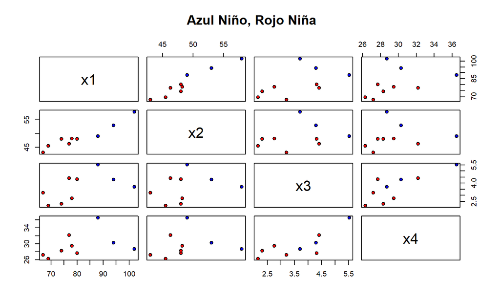

## Cálculos básicos

En lo que sigue todos los datos se redondean al tercer decimal.

Daremos el código de R que realiza el cálculo, en el código no se redondea: La matriz centrada de los datos anteriores es:

\[ \tilde{\mathbf{X}}= \left( \begin{array}{rrrr} -3.000 & -0.578 & -0.881 & -0.133 \\ -12.000 & -3.278 & -1.481 & -3.333 \\ -4.000 & -2.478 & 0.779 & 2.567 \\ 7.000 & 0.222 & 1.889 & 6.867 \\ -14.000 & -5.778 & -0.421 & -2.433 \\ -1.000 & -0.778 & 0.689 & -1.933 \\ -7.000 & -0.778 & -1.321 & -1.333 \\ 13.000 & 4.222 & 0.669 & 0.667 \\ 21.000 & 9.222 & 0.079 & -0.933 \end{array} \right) \]

## Cálculos básicos

```r
colMeans(X)
```

```
## [1] 81.000000 48.777778  3.631111 29.633333
```

```r
n=dim(X)[1]
n
```

```
## [1] 9
```

```r
Hn=diag(rep(1,n))-1/n# matriz centralizadora
dim(Hn)
```

```
## [1] 9 9
```

## Cálculos básicos

```r
# filas 1 a 9 y columnas 1 a 4
# de la matriz centralizadora
round(Hn[1:9,1:4],4)
```

```
##          [,1]    [,2]    [,3]    [,4]
##  [1,]  0.8889 -0.1111 -0.1111 -0.1111
##  [2,] -0.1111  0.8889 -0.1111 -0.1111
##  [3,] -0.1111 -0.1111  0.8889 -0.1111
##  [4,] -0.1111 -0.1111 -0.1111  0.8889
##  [5,] -0.1111 -0.1111 -0.1111 -0.1111
##  [6,] -0.1111 -0.1111 -0.1111 -0.1111
##  [7,] -0.1111 -0.1111 -0.1111 -0.1111
##  [8,] -0.1111 -0.1111 -0.1111 -0.1111
##  [9,] -0.1111 -0.1111 -0.1111 -0.1111
```

## Cálculos básicos

```r
cX=Hn%*%X # matriz centrada cálculo matricial
round(cX,3)
```

```
##       [,1]   [,2]   [,3]   [,4]
##  [1,]   -3 -0.578 -0.881 -0.133
##  [2,]  -12 -3.278 -1.481 -3.333
##  [3,]   -4 -2.478  0.779  2.567
##  [4,]    7  0.222  1.889  6.867
##  [5,]  -14 -5.778 -0.421 -2.433
##  [6,]   -1 -0.778  0.689 -1.933
##  [7,]   -7 -0.778 -1.321 -1.333
##  [8,]   13  4.222  0.669  0.667
##  [9,]   21  9.222  0.079 -0.933
```

## Ejemplo

- La matriz de covarianzas de los datos anteriores es:

\[ \mathbf{S}= \begin{pmatrix} 119.333 & 43.133 & 6.148 & 12.511 \\ 43.133 & 17.193 & 1.148 & 1.886 \\ 6.148 & 1.148 & 1.111 & 2.428 \\ 12.511 & 1.886 & 2.428 & 8.624 \end{pmatrix} \]

- Los valores propios son:

\[\lambda_1=136.615,\quad \lambda_2=8.861,\quad \lambda_3 = 0.738,\quad \lambda_4 = 0.047.\]

## Ejemplo

- Los vectores propios ortonormales correspondientes a los valores propios, son las columnas de la siguiente matriz:

\[ \left( \begin{array}{rrrr} 0.934 & -0.022 & 0.256 & 0.247 \\ 0.339 & 0.354 & -0.661 & -0.568 \\ 0.047 & -0.248 & 0.566 & -0.785 \\ 0.097 & -0.902 & -0.421 & -0.013 \end{array} \right) \]

## Ejemplo

```
##            [,1]      [,2]     [,3]      [,4]
## [1,] 119.333333 43.133333 6.147778 12.511111
## [2,]  43.133333 17.192840 1.147802  1.886296
## [3,]   6.147778  1.147802 1.110610  2.427852
## [4,]  12.511111  1.886296 2.427852  8.624444
```

```
## eigen() decomposition
## $values
## [1] 136.61529623   8.86125966   0.73789460   0.04677667
##
## $vectors
##            [,1]        [,2]       [,3]        [,4]
## [1,] 0.93439437 -0.02238785  0.2555755  0.24715806
## [2,] 0.33947477  0.35413519 -0.6610845 -0.56772562
## [3,] 0.04701065 -0.24770838  0.5656945 -0.78512437
## [4,] 0.09723192 -0.90151407 -0.4214714 -0.01342527
```

## Ejemplo

- Las expresiones de las variables nuevas \(CP_i\) en función de las antiguas, notemos que se calculan sobre los datos centrados, son:

\[ \begin{array}{rl} CP_1 = & 0.934\cdot \tilde{X}_1 + 0.339\cdot \tilde{X}_2 + 0.047\cdot \tilde{X}_3\\ & + 0.097 \cdot \tilde{X}_4, \\ CP_2 = & -0.022\cdot \tilde{X}_1 +0.354\cdot \tilde{X}_2 -0.248 \cdot \tilde{X}_3 \\ & -0.902 \cdot \tilde{X}_4, \\ CP_3 = & 0.256\cdot \tilde{X}_1 -0.661 \cdot \tilde{X}_2 +0.566\cdot \tilde{X}_3 \\ &-0.421\cdot \tilde{X}_4, \\ CP_4 = & 0.247 \cdot \tilde{X}_1 - 0.568\cdot \tilde{X}_2 - 0.785\cdot \tilde{X}_3 \\ & - 0.013 \cdot \tilde{X}_4. \end{array} \]

## Ejemplo

- La nueva matriz de datos respecto de las nuevas variables será:

\[ \mathbf{CP}= \tilde{\mathbf{X}} \mathbf{u} = \left( \begin{array}{rrrr} -3.054 & 0.201 & -0.827 & 0.280 \\ -12.719 & 2.480 & -0.333 & 0.103 \\ -4.293 & -3.295 & -0.025 & -0.228 \\ 7.373 & -6.736 & -0.183 & 0.029 \\ -15.299 & 0.565 & 1.029 & 0.183 \\ -1.354 & 1.319 & 1.463 & -0.321 \\ -6.997 & 1.411 & -1.460 & -0.233 \\ 13.677 & 0.437 & 0.629 & 0.282 \\ 22.666 & 3.618 & -0.292 & -0.095 \\ \end{array} \right) \]

## Ejemplo

- Se puede observar que si se multiplican escalarmente dos columnas cualesquiera, el resultado es nulo. Es decir, las columnas de la nueva matriz de datos son ortogonales dos a dos.

```
##             [,1]       [,2]        [,3]        [,4]
##  [1,]  -3.053710  0.2010126 -0.82701014  0.28011692
##  [2,] -12.719190  2.4798083 -0.33296991  0.10258907
##  [3,]  -4.292542 -3.2947403 -0.02544479 -0.22791715
##  [4,]   7.372657 -6.7363084 -0.18344827  0.02874558
##  [5,] -15.299325  0.5653125  1.02890237  0.18327243
##  [6,]  -1.354027  1.3192330  1.46314663 -0.32050161
##  [7,]  -6.996545  1.4105455 -1.46023526 -0.23340514
##  [8,]  13.676731  0.4374966  0.62864176  0.28187987
##  [9,]  22.665952  3.6176402 -0.29158239 -0.09477995
```

## Ejemplo

Como podemos observar, nuestro análisis que interpretado por la variable de perfil sexo ya que distingue entre niños y niñas con las dos primeras componentes.

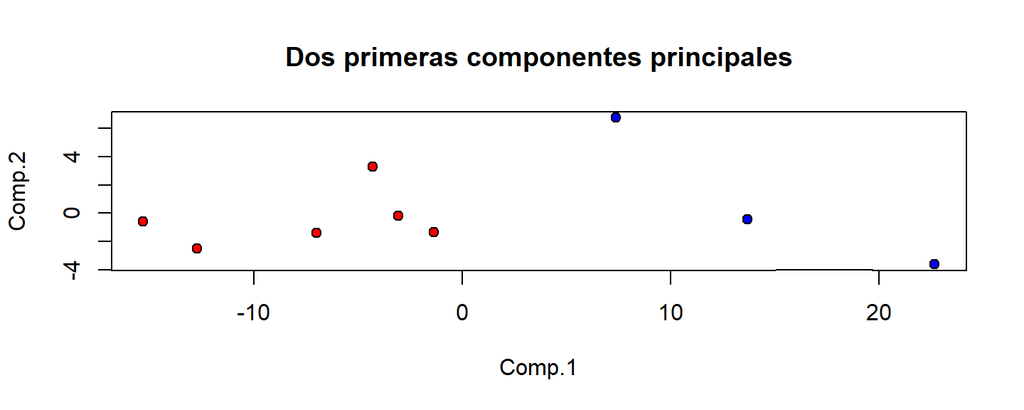

## Ejemplo

El siguiente código dibuja todos los componentes

```r
pairs(solacp$scores,pch=21,
bg = c("red", "blue")[unclass(Datos$Sexo)],
main="Diagrama matricial de
los componentes principales")
```

## Ejemplo

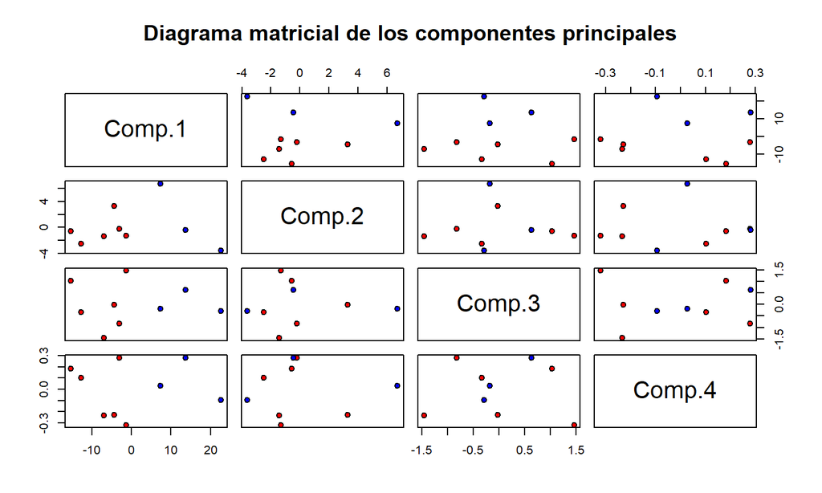

## ACP correlaciones.

## ACP correlaciones.

Sea \(\mathbf{R}\) la matriz de correlaciones de orden \(p\). Calcularemos sus valores propios

\[\lambda_1\geq \lambda_2\geq\ldots\geq\lambda_p.\]

y los correspondientes vectores propios ortonormales.

\[\mathbf{u}_1,\mathbf{u}_2,\ldots,\mathbf{u}_p.\]

Las direcciones de los componentes principales quedan determinadas por el vector propio correspondiente.

## ACP correlaciones.

\[\mathbf{CP}= \mathbf{Z} \mathbf{u},\] donde \(Z\) es la matriz de datos tipificados y \(\mathbf{u}\) es la matriz de los vectores propios.

## Ejemplo

- Realicemos un análisis ACP de correlaciones con el ejemplo anterior.
- La matriz tipificada de datos es: \[ \mathbf{Z}= \left( \begin{array}{rrrr} -0.275 & -0.139 & -0.836 & -0.045 \\ -1.099 & -0.791 & -1.405 & -1.135 \\ -0.366 & -0.598 & 0.739 & 0.874 \\ 0.641 & 0.054 & 1.792 & 2.338 \\ -1.282 & -1.393 & -0.400 & -0.829 \\ -0.092 & -0.188 & 0.654 & -0.658 \\ -0.641 & -0.188 & -1.254 & -0.454 \\ 1.190 & 1.018 & 0.635 & 0.227 \\ 1.922 & 2.224 & 0.075 & -0.318 \end{array} \right) \]

## Ejemplo

- La matriz de correlaciones \(\mathbf{R}\) vale, en este caso: \[ \mathbf{R} = \left( \begin{array}{rrrr} 1.000 & 0.952 & 0.534 & 0.390 \\ 0.952 & 1.000 & 0.263 & 0.155 \\ 0.534 & 0.263 & 1.000 & 0.784 \\ 0.390 & 0.155 & 0.784 & 1.000 \end{array} \right) \]
- Los valores propios de dicha matriz son: \[ 2.560,\quad 1.229,\quad 0.208,\quad 0.00325. \]
- La matriz de los vectores propios es: \[ \left( \begin{array}{rrrr} 0.573 & 0.359 & -0.038 & 0.736 \\ 0.478 & 0.578 & 0.145 & -0.646 \\ 0.499 & -0.459 & -0.707 & -0.201 \\ 0.442 & -0.572 & 0.691 & -0.029 \end{array} \right) \]

## Ejemplo

- Las expresiones de las variables nuevas \(CP_i\) en función de las antiguas \(Z_i\)son:

\[ \begin{array}{rl} CP_1 = & 0.573\cdot Z_1 +0.478\cdot Z_2 +0.499\cdot Z_3\\ & +0.442 \cdot Z_4, \\ CP_2 = & 0.359\cdot Z_1 + 0.578\cdot Z_2 -0.459 \cdot Z_3 \\ & -0.572 \cdot Z_4, \\ CP_3 = & -0.038\cdot Z_1 +0.145 \cdot Z_2 -0.707\cdot Z_3 \\ &+0.691\cdot Z_4, \\ CP_4 = & 0.736 \cdot Z_1 - 0.646\cdot Z_2 - 0.201\cdot Z_3 \\ & - 0.029 \cdot Z_4. \end{array} \]

## Ejemplo

- La nueva matriz de datos respecto de las nuevas variables será:

\[ \mathbf{CP} = \mathbf{Z} \mathbf{u} = \begin{pmatrix} -0.661 & 0.231 & 0.550 & 0.057 \\ -2.209 & 0.443 & 0.137 & 0.018 \\ 0.259 & -1.316 & 0.008 & -0.058 \\ 2.319 & -1.899 & 0.332 & 0.008 \\ -1.965 & -0.608 & -0.444 & 0.061 \\ -0.107 & -0.065 & -0.941 & -0.058 \\ -1.282 & 0.497 & 0.570 & -0.085 \\ 1.585 & 0.594 & -0.189 & 0.084 \\ 2.061 & 2.122 & -0.023 & -0.027 \end{pmatrix} \]

- Se puede observar que si calculamos el productoescalar de dos columnas cualesquiera, es resultado es nulo. Es decir, las columnas de la nueva matriz de datos son ortogonales dos a dos.

## Propiedades ACP covarianzas.

## Propiedades ACP covarianzas.

Sea \(\mathbf{X}\) una matriz de datos \(n\times p\) y sea

\[ \mathbf{S}=\begin{pmatrix} s_1^2& s_{ 1 2}&\ldots &s_{1 p}\\ s_{2 1}& s_{2}^2&\ldots &s_{2 p}\\ \vdots & \vdots &\ddots & \vdots\\ s_{p 1}& s_{ p 2}&\ldots &s_{p}^2 \end{pmatrix} \] su matriz de covarianzas.

Recordemos que \(s_i^2\) es la varianza de la variable \(\mathbf{x}_i\) y que \(s_{i j}\) son las covarianzas de la variables \(\mathbf{x}_i\) y \(\mathbf{x}_j\).

Además la \(\mbox{Varianza Total}= tr(\mathbf{S})=\sum_{i=1}^p s_i^2\)

## Propiedades ACP covarianzas.

- \(Var(\mathbf{CP}_i)= \lambda_i\). La varianza de cada componente principal es su valor propio.
- \(\sum_{i=1}^n Var(\mathbf{CP}_i)=\sum_{i=1}^n \lambda_i=tr(\mathbf{S})=\sum_{i=1}^n s_i^2\). Por lo tanto los componentes principales reproducen la varianza total
- Los componentes principales tienen correlación cero entre sí (son *incorrelados*) por lo tanto su matriz de covarianzas es \[\mathbf{S}_{CP}=\left(\begin{array}{cccc} \lambda_1& 0 &\ldots &0\\ 0& \lambda_{2}&\ldots & 0\\ \vdots & \vdots & & \vdots\\ 0 & 0&\ldots &\lambda_{p} \end{array} \right)\]

## Propiedades ACP covarianzas.

- \(\det(\mathbf{S}_{CP})=\prod_{i=1}^n \lambda_i =\det(\mathbf{S})\). Luego los componentes principales conservan la varianza generalizada.
- La proporción de varianza explicada por la componente \(j\)-ésima es \[\frac{\lambda_j}{\sum_{i=1}^n \lambda_i}.\]

Además al ser* incorrelados* la proporción de varianza explicada por los \(k\) primeros componentes es \[\frac{\sum_{i=1}^k \lambda_i}{\sum_{i=1}^n \lambda_i}.\]

- \(\mbox{Cov}(\tilde{\mathbf{X}}_i, \mathbf{CP}_j)=\lambda_j u_{j i}\); \(corr(\tilde{\mathbf{X}}_i, \mathbf{CP}_j)=\frac{\sqrt{\lambda_j} u_{j i}}{s_i}\) donde \(u_{j i}\) es la \(i\)-ésima componente del vector propio \(\mathbf{u}_j\).

## Ejemplo

Vamos a comprobar las propiedades anteriores con nuestro ejemplo. Recordemos las matrices de datos de las variables originales \(\mathbf{X}\) (centradas) y de las variables en componentes principales \(\mathbf{CP}\): \[ {\tiny \begin{array}{rl} \tilde{\mathbf{X}} =& \left( \begin{array}{rrrr} -3.000 & -0.578 & -0.881 & -0.133 \\ -12.000 & -3.278 & -1.481 & -3.333 \\ -4.000 & -2.478 & 0.779 & 2.567 \\ 7.000 & 0.222 & 1.889 & 6.867 \\ -14.000 & -5.778 & -0.421 & -2.433 \\ -1.000 & -0.778 & 0.689 & -1.933 \\ -7.000 & -0.778 & -1.321 & -1.333 \\ 13.000 & 4.222 & 0.669 & 0.667 \\ 21.000 & 9.222 & 0.079 & -0.933 \end{array} \right) , \\ &\\ \mathbf{CP}= & \left( \begin{array}{rrrr} -3.054 & 0.201 & -0.827 & 0.280 \\ -12.719 & 2.480 & -0.333 & 0.103 \\ -4.293 & -3.295 & -0.025 & -0.228 \\ 7.373 & -6.736 & -0.183 & 0.029 \\ -15.299 & 0.565 & 1.029 & 0.183 \\ -1.354 & 1.319 & 1.463 & -0.321 \\ -6.997 & 1.411 & -1.460 & -0.233 \\ 13.677 & 0.437 & 0.629 & 0.282 \\ 22.666 & 3.618 & -0.292 & -0.095 \end{array} \right). \end{array}} \]

## Ejemplo

\[ cov(\mathbf{CP})= \left( \begin{array}{rrrr} 136.615 & 0.000 & 0.000 & 0.000 \\ 0.000 & 8.861 & 0.000 & 0.000 \\ 0.000 & 0.000 & 0.738 & 0.000 \\ 0.000 & 0.000 & 0.000 & 0.047 \end{array} \right) \]

Podemos observar que es una matriz diagonal con los valores propios de la matriz \(\mathbf{S}\) en la diagonal.

## Ejemplo

- La matriz de covarianzas entre las variables \(\tilde{\mathbf{X}}\) y \(\mathbf{CP}\) vale: \[ cov(\tilde{\mathbf{X}},\mathbf{CP})= \left( \begin{array}{rrrr} 127.653 & -0.198 & 0.189 & 0.012 \\ 46.377 & 3.138 & -0.488 & -0.027 \\ 6.422 & -2.195 & 0.417 & -0.037 \\ 13.283 & -7.989 & -0.311 & -0.001 \end{array} \right) \]

Recuperemos la matriz de vectores propios de la matriz \(\mathbf{S}\):

\[ {\tiny \left( \begin{array}{rrrr} 0.934 & -0.022 & 0.256 & 0.247 \\ 0.339 & 0.354 & -0.661 & -0.568 \\ 0.047 & -0.248 & 0.566 & -0.785 \\ 0.097 & -0.902 & -0.421 & -0.013 \end{array} \right) .} \]

## Ejemplo

Si multiplicamos la primera columna de la matriz anterior

\[ \begin{pmatrix} 0.934\\ 0.339\\ 0.047\\ 0.097 \end{pmatrix} \]

por el valor propio \(136.615\) de la matriz \(\mathbf{S}\) obtenemos la primera columna de la matriz

\(\mbox{Cov}(\tilde{\mathbf{X}},\mathbf{CP})\):

\[ 136.615\cdot \begin{pmatrix}0.934\\ 0.339\\ 0.047\\ 0.097\end{pmatrix}= \begin{pmatrix} 127.652 \\ 46.377 \\ 6.422 \\ 13.283 \end{pmatrix} \]

## Ejemplo

- En general, tenemos que

\[ \mathbf{u}\cdot \mbox{diag}(\lambda) = \mbox{Cov}(\tilde{\mathbf{X}},\mathbf{CP}), \]

donde \(\mathbf{u}\) es la matriz formada por los vectores propios de la matriz \(\mathbf{S}\) y \(\mbox{diag}(\lambda)\) es una matriz diagonal con los valores propios de la matriz \(\mathbf{S}\) en la diagonal.

## Propiedades ACP correlaciones.

## Propiedades ACP correlaciones.

Sea \(\mathbf{X}\) una matriz de datos \(n\times p\) y sea

\[\mathbf{R}=\left(\begin{array}{cccc} 1& r_{ 1 2}&\ldots &r_{1 p}\\ r_{2 1}& 1&\ldots &r_{2 p}\\ \vdots & \vdots & \ddots& \vdots\\ r_{p 1}& s_{ p 2}&\ldots &1 \end{array} \right)\] Su matriz de correlaciones. Se verifican las siguientes propiedades:

## Propiedades ACP correlaciones

- Recordemos que la diagonal es \(1\) pues es la varianza de los datos tipificados y que \(r_{i j}\) son las correlaciones lineales de la variables \(\mathbf{x}_i\) y \(\mathbf{x}_j\).
- Además la \(\mbox{Varianza Total}= tr(\mathbf{R})=p\)
- \(Var(\mathbf{CP}_i)= \lambda_i\). El valor propio del componente es igual a su varianza
- \(\sum_{i=1}^n var(\mathbf{CP}_i)=\sum_{i=1}^n \lambda_i=tr(\mathbf{R})=p\). Por lo tanto los componentes principales reproducen la varianza total y ésta es igual al numero de variables \(p\).

## Propiedades ACP correlaciones.

- Los componentes principales tienen correlación cero entre sí (son *incorrelados*) por lo tanto su matriz de covarianzas ( que este caso es igual a la de correlaciones es

\[\mathbf{S}_{CP}=\left(\begin{array}{cccc} \lambda_1& 0 &\ldots &0\\ 0& \lambda_{2}&\ldots & 0\\ \vdots & \vdots &\ddots & \vdots\\ 0 & 0&\ldots &\lambda_{p} \end{array} \right)\]

## Propiedades ACP correlaciones.

- \(\det(\mathbf{S}_{CP})=\prod_{i=1}^n \lambda_i =\det(\mathbf{R})\). Luego los componentes principales conservan la varianza generalizada.
- La proporción de varianza explicada por cada componente es \[\frac{\lambda_i}{p}.\]

Además al ser *incorreladas* la proporción de varianza explicada por los \(k\) primeros componentes es \[\frac{\sum_{i=1}^k \lambda_i}{p}.\]

- \(corr(\mathbf{Z}_i, \mathbf{CP}_j)=\sqrt{\lambda_j}\cdot u_{j i}\) donde \(u_{j i}\) es la \(i\)-ésima componente del vector propio \(\mathbf{u}_j\).

## Propiedades ACP correlaciones.

Vamos a comprobar las propiedades anteriores con nuestro ejemplo. Recordemos las matrices de datos estandarizada\(\mathbf{Z}\)y de las variables en componentes principales \(\mathbf{CP}\):

\[ \mathbf{Z}= \begin{pmatrix} -0.275 & -0.139 & -0.836 & -0.045 \\ -1.099 & -0.791 & -1.405 & -1.135 \\ -0.366 & -0.598 & 0.739 & 0.874 \\ 0.641 & 0.054 & 1.792 & 2.338 \\ -1.282 & -1.393 & -0.400 & -0.829 \\ -0.092 & -0.188 & 0.654 & -0.658 \\ -0.641 & -0.188 & -1.254 & -0.454 \\ 1.190 & 1.018 & 0.635 & 0.227 \\ 1.922 & 2.224 & 0.075 & -0.318 \end{pmatrix} \]

## Ejemplo

\[ \mathbf{CP}= \begin{pmatrix} -0.661 & 0.231 & 0.550 & 0.057 \\ -2.209 & 0.443 & 0.137 & 0.018 \\ 0.259 & -1.316 & 0.008 & -0.058 \\ 2.319 & -1.899 & 0.332 & 0.008 \\ -1.965 & -0.608 & -0.444 & 0.061 \\ -0.107 & -0.065 & -0.941 & -0.058 \\ -1.282 & 0.497 & 0.570 & -0.085 \\ 1.585 & 0.594 & -0.189 & 0.084 \\ 2.061 & 2.122 & -0.023 & -0.027 \end{pmatrix}. \]

## Ejemplo

\[ \begin{array}{llcll} \mbox{Var}(\mathbf{CP}_1) & =2.560,\ & \mbox{Var}(\mathbf{CP}_2) & =1.229,\\ \mbox{Var}(\mathbf{CP}_3) & =0.208,\ & \mbox{Var}(\mathbf{CP}_4) & =0.00325, \end{array} \]

## Ejemplo

\[ \mbox{Cov}(\mathbf{CP})= \mathbf{S}_{\mathbf{CP}} = \begin{pmatrix} 2.560 & 0.000 & 0.000 & 0.000 \\ 0.000 & 1.229 & 0.000 & 0.000 \\ 0.000 & 0.000 & 0.208 & 0.000 \\ 0.000 & 0.000 & 0.000 & 0.003 \end{pmatrix}, \]

## Ejemplo

\[\textcolor{red}{\det(\mathbf{S}_{\mathbf{CP}})=0.00213},\]

\[ \prod_{i=1}^4\lambda_i= 2.560\cdot 1.229\cdot 0.208\cdot 0.00325 = 0.00213. \]

## Ejemplo

La matriz de correlaciones entre las variables \(\mathbf{Z}\) y \(\mathbf{CP}\) es:

\[ \mbox{Cor}(\mathbf{Z},\mathbf{CP}) = \begin{pmatrix} 0.916 & 0.398 & -0.017 & 0.042 \\ 0.764 & 0.641 & 0.066 & -0.037 \\ 0.798 & -0.509 & -0.323 & -0.011 \\ 0.706 & -0.634 & 0.315 & -0.002 \end{pmatrix}. \]

La matriz de vectores propios de la matriz \(\mathbf{ R}\) es:

\[ \begin{pmatrix} 0.573 & 0.359 & -0.038 & 0.736 \\ 0.478 & 0.578 & 0.145 & -0.646 \\ 0.499 & -0.459 & -0.707 & -0.201 \\ 0.442 & -0.572 & 0.691 & -0.029 \end{pmatrix}. \]

## Ejemplo

Si multiplicamos la primera columna de la matriz anterior

\[\begin{pmatrix}0.573 \\ 0.478\\ 0.499 \\ 0.442\end{pmatrix}\]

por la raíz cuadrada del primer valor propio de la matriz \(\mathbf{R}\), \(\sqrt{2.560}\), obtenemos la primera columna de la matriz

\[\mbox{Cor}(\mathbf{Z},\mathbf{CP}),\]

efectivamente

## Ejemplo

\[ \sqrt{2.560}\cdot \begin{pmatrix}0.573 \\ 0.478\\ 0.499 \\ 0.442\end{pmatrix} = \textcolor{red}{\begin{pmatrix}0.916 \\ 0.764\\ 0.798 \\ 0.706\end{pmatrix}} \]

\[ Cor(\mathbf{Z},\mathbf{CP}) = \begin{pmatrix} \textcolor{red}{0.916} & 0.398 & -0.017 & 0.042 \\ \textcolor{red}{0.764} & 0.641 & 0.066 & -0.037 \\ \textcolor{red}{0.798} & -0.509 & -0.323 & -0.011 \\ \textcolor{red}{0.706} & -0.634 & 0.315 & -0.002 \end{pmatrix} \]

## Ejemplo

- En general, podemos escribir:

\[ \mathbf{u}\cdot \mbox{diag}(\sqrt{\lambda}) = \mbox{Cor}(\mathbf{Z},\mathbf{CP}), \]

donde \(\mathbf{u}\) es la matriz formada por los vectores propios de la matriz \(\mathbf{R}\) y \(\mbox{diag}(\sqrt{\lambda})\) es una matriz diagonal con la raíz cuadrada de los valores propios de la matriz \(\mathbf{R}\) en la diagonal.

## Propiedades ACP correlaciones

- La primera componente principal es la recta que conserva mayor inercia de la nube de puntos.
- Los dos primeros componentes principales forman el plano que conserva mayor inercia de la nube de puntos.
- Lo mismo sucede con los espacios formados por los \(k\) primeros componentes

## Etapas de un ACP

## Etapas de un ACP

- Determinar las variables e individuos que intervienen en el análisis, las variables de perfil y los individuos ilustrativos.
- Decidir si se realiza el análisis sobre los datos brutos (matriz de covarianzas) o sobre los datos tipificados (matriz de correlaciones).
- Cuando las variables originales \(\mathbf{X}\) están medidas en distintas unidades, conviene aplicar el análisis de correlaciones. Si están en las mismas unidades, ambas alternativas son posibles.
- Si las diferencias entre las varianzas son informativas y queremos tenerlas en cuenta en el análisis, no debemos estandarizar las variables.

## Retención de componentes

## Retención de componentes

- En el ejemplo que hemos desarrollado, tenemos que con un análisis de covarianzas, si sólo elegimos la primera componente, cubrimos el \(93.4\%\) de la varianza. Si elegimos, las dos primeras, cubrimos el \(99.5\%\) de la varianza. Con las tres primeras, cubrimos el \(99.9\%\) de la varianza.
- En cambio, con un análisis de correlaciones, con la primera componente, sólo cubrimos el \(64\%\) de la varianza; con las dos primeras, el \(94.7\%\) de la varianza y con las tres primeras, el \(99.9\%\) de la varianza.

## Técnicas de retención de reteción de componentes

## Retención de componentes

- Se retienen todas las componentes \(\mathbf{CP}_i\) que cumplan \(\lambda_i\geq\overline{\lambda}=\frac{\sum_{i=1}^p \lambda_i}{p}\)
- En el caso del análisis de correlaciones, la condición anterior equivale a retener los componentes con valores propios mayores que 1.

## Retención de componentes

- En nuestro ejemplo, para el análisis de covarianzas, tenemos que: \(\overline{\lambda}=36.565\). Recordemos que los valores propios de la matriz de covarianzas \(\mathbf{S}\) son: \[136.615,\ 8.861,\ 0.738,\ 0.0468.\] Por tanto, tenemos que retener sólo la componente \(\mathbf{CP}_1\).
- Para el análisis de correlaciones, recordemos que los valores propios de la matriz \(\mathbf{R}\) son: \[2.560,\ 1.229,\ 0.208,\ 0.00324.\] En este caso, tenemos que retener los componentes \(\mathbf{CP}_1\) y \(\mathbf{CP}_2\).

## Gráfico de sedimentación, regla del codo, código

```r
screeplot(solacp,type="lines",
          main="Gráfico de sedimentación")
screeplot(solacp,type="barplot",
          main="Gráfico de sedimentación",ylim=c(0,150))
```

## Gráfico de sedimentación, regla del codo, poligonal.

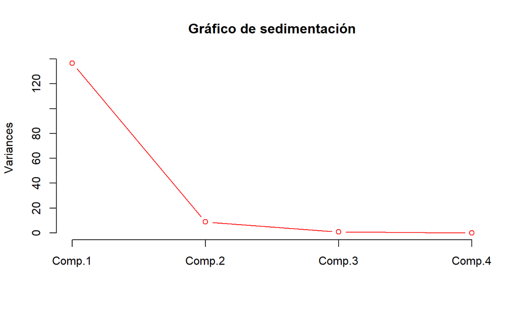

## Gráfico de sedimentación, regla del codo, barras.

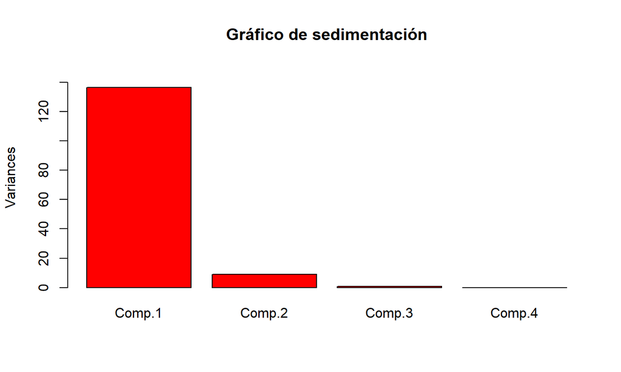

Hay muchas otras pruebas más como la pruebas de Hipótesis de Anderson:

\[\left\{ \begin{array}{l} H_0: \lambda_m=\ldots=\lambda_p\\ H_1: \mbox{no todos iguales}\end{array}\right.\]

## Adecuación de los datos al ACP

## Adecuación de los datos al ACP

\[KMO=\frac{\sum_j \sum_{i\not =j} r_{i j}^2}{\sum_j \sum_{i\not =j} r^2_{i j}+ \sum_j \sum_{i\not =j} a^2_{i j}}\]

donde \(r_{i j}\) son los coef. de correlación entre las variables \(i\) y \(j\), mientras quelos \(a_{i j}\) son los coef. de correlación parcial entre las variables \(i\) y \(j\) (equivalentes a las correlaciones entre los residuos de la regresiones de estas dos variables con las restantes).

## Adecuación de los datos al ACP

- Niveles de KMO \(\geq 0.5\) son considerados aceptables.

En nuestro ejemplo, las correlaciones parciales son:

```r
library(corpcor)
cor2pcor(cor(X))
```

```
##           [,1]       [,2]        [,3]        [,4]
## [1,] 1.0000000  0.9957943  0.90468746  0.31170534
## [2,] 0.9957943  1.0000000 -0.89188935 -0.31783572
## [3,] 0.9046875 -0.8918894  1.00000000  0.03389341
## [4,] 0.3117053 -0.3178357  0.03389341  1.00000000
```

## Adecuación de los datos al ACP

Crearemos una funcióin quew calcule el KMO:

```r
kmo.test <- function(df){
cor.sq = cor(df)^2
cor.sumsq = (sum(cor.sq)-dim(cor.sq)[1])
pcor.sq = cor2pcor(cor(df))^2
pcor.sumsq = (sum(pcor.sq)-dim(pcor.sq)[1])
kmo = cor.sumsq/(cor.sumsq+pcor.sumsq)
return(kmo)
}

kmo.test(X)
```

```
## [1] 0.4225498
```

El testde esfericidad de Barlett contrasta si la matriz de correlaciones es la identidad.

\[\left\{ \begin{array}{l} H_0: \mbox{La matriz de correlaciones es la identidad}\\\\ H_1: \mbox{es distinta de la identidad}\end{array}\right.\]

Para que el ACP sea útil interesa rechazar la hipótesis nula, pues si \(\mathbf{R}=I\) los componentes principales son las propias variables y no se produce una reducción de los factores.

Este test, al igual que casi todas las propiedades de los estimadores en ACP, requiere multinormalidad en la distribución de las variables.

En nuestro ejemplo:

```r
library(psych)
cortest.bartlett(cor(X),n=n)
```

```
## $chisq
## [1] 35.89478
##
## $p.value
## [1] 2.889513e-06
##
## $df
## [1] 6
```

El \(p\)-valor es muy pequeño por lo que no podemos aceptar la hipóstesi nula, la matriz de correlaciones es significativamente distinta de la identidad.

## Descomposición en valores singulares (SVD)

## Descomposición en valores singulares

Dada un matriz de datos \(\mathbf{X}\) de dimensiones \(n\times p\), donde \(n\geq p\) y de rango \(p\), se puede descomponer en producto de tres matrices:

\[ \mathbf{X}=\mathbf{U}\cdot \Sigma\cdot \mathbf{V}^t, \mbox{ donde} \]

- \(\mathbf{U}\) es una matriz ortogonal \(n\times p\) que tiene por columnas los \(p\) vectores propios de la matriz \(\mathbf{X}\mathbf{X}^t\) asociados a los \(p\) valores propios no nulos.
- \({\Sigma}\) es una matriz diagonal \(p\times p\) que tiene por diagonal las raíces cuadradas de los valores propios de la matriz \(\mathbf{X}^t\mathbf{X}\).
- \(\mathbf{V}\) es una matriz ortogonal \(p\times p\) que tiene por columnas los vectores propios de la matriz \(\mathbf{X}^t\cdot \mathbf{X}\) asociados a los \(p\) valores propios no nulos.

## Descomposición en valores singulares (SVD): ejemplo

Consideramos la matriz \(\mathbf{X}\) como la matriz de datos centrada del ejemplo de los niños.

```
##       [,1]       [,2]        [,3]       [,4]
##  [1,]   -3 -0.5777778 -0.88111111 -0.1333333
##  [2,]  -12 -3.2777778 -1.48111111 -3.3333333
##  [3,]   -4 -2.4777778  0.77888889  2.5666667
##  [4,]    7  0.2222222  1.88888889  6.8666667
##  [5,]  -14 -5.7777778 -0.42111111 -2.4333333
##  [6,]   -1 -0.7777778  0.68888889 -1.9333333
##  [7,]   -7 -0.7777778 -1.32111111 -1.3333333
##  [8,]   13  4.2222222  0.66888889  0.6666667
##  [9,]   21  9.2222222  0.07888889 -0.9333333
```

## Descomposición en valores singulares (SVD): ejemplo

La matriz \(\mathbf{X}^t\cdot \mathbf{X}\) vale:

\[ \mathbf{X}^t\cdot \mathbf{X}=\begin{pmatrix} 1074.000 & 388.200 & 55.330 & 112.600 \\ 388.200 & 154.736 & 10.330 & 16.977 \\ 55.330 & 10.330 & 9.995 & 21.851 \\ 112.600 & 16.977 & 21.851 & 77.620 \end{pmatrix} \]

## Descomposición en valores singulares (SVD): ejemplo

La matriz \(\mathbf{X}\cdot \mathbf{X}^t\) vale: (mostramos solo las 4 primeras columnas, la dimesión es \(9\times 9\))

\[ {\footnotesize \mathbf{X}\cdot \mathbf{X}^t=\begin{pmatrix} 10.128 & 39.643 & 12.403 & -23.708 \\ 39.643 & 168.049 & 46.412 & -110.415 \\ 12.403 & 46.412 & 29.334 & -9.455 \\ -23.708 & -110.415 & -9.455 & 99.768 \\ 46.034 & 195.673 & 63.742 & -116.788 \\ 3.100 & 19.974 & 1.502 & -19.147 \\ 22.791 & 92.951 & 25.476 & -60.824 \\ -42.118 & -173.052 & -60.230 & 97.780 \\ -68.273 & -279.234 & -109.185 & 142.790 \end{pmatrix} } \]

## Descomposición en valores singulares (SVD): ejemplo

Los valores propios de la matriz \(\mathbf{X}^t\mathbf{X}\) son:

Por lo tanto, la matriz \(\Sigma\) será:

\[ \Sigma =\begin{pmatrix} 35.065 & 0.000 & 0.000 & 0.000 \\ 0.000 & 8.930 & 0.000 & 0.000 \\ 0.000 & 0.000 & 2.577 & 0.000 \\ 0.000 & 0.000 & 0.000 & 0.649 \end{pmatrix} \]

## Descomposición en valores singulares (SVD): ejemplo

\[ \mathbf{U} =\begin{pmatrix} -0.087 & 0.017 & 0.332 & 0.426 \\ -0.362 & 0.279 & 0.129 & 0.159 \\ -0.123 & -0.360 & -0.003 & -0.354 \\ 0.208 & -0.750 & 0.067 & 0.036 \\ -0.436 & 0.076 & -0.420 & 0.294 \\ -0.038 & 0.140 & -0.558 & -0.485 \\ -0.199 & 0.153 & 0.577 & -0.370 \\ 0.391 & 0.022 & -0.203 & 0.434 \\ 0.647 & 0.424 & 0.079 & -0.140 \end{pmatrix} \]

## Descomposición en valores singulares (SVD): ejemplo

La matriz \(\mathbf{V}\) será la siguiente matriz \(4\times 4\) d elos valores propios de \(X^t\cdot X\) :

\[ \mathbf{V} =\begin{pmatrix} 0.934 & -0.022 & 0.256 & 0.247 \\ 0.339 & 0.354 & -0.661 & -0.568 \\ 0.047 & -0.248 & 0.566 & -0.785 \\ 0.097 & -0.902 & -0.421 & -0.013 \end{pmatrix} \] Comprobar que \(\mathbf{X}=\mathbf{U}\Sigma\mathbf{V}t\).

## Relación ACP con SVD

La prueba es muy sencilla. Recordamos que las componentes principales son: \(\mathbf{CP}=\mathbf{X}\mathbf{V}\), donde \(\mathbf{V}\) era la matriz de vectores propios de la matriz de covarianzas

\[\mathbf{S}=\frac{1}{n}\mathbf{X}^t\cdot \mathbf{X}.\]

Ahora bien, esta matriz coincidirá con la matriz de vectores propios de la matriz \(\mathbf{X}t\mathbf{X}\) puesto que los vectores propios de la matriz anterior y de la matriz de covarianzas \(\mathbf{S}\) son los mismos.

Por lo tanto,

\[\mathbf{Y}=\mathbf{X}\mathbf{V}=\mathbf{U}\Sigma\mathbf{V}t\mathbf{V}=\mathbf{U}\Sigma,\] puesto que la matriz \(\mathbf{V}\) es ortogonal.

## Relación ACP con SVD

**Prueba**

## Ejemplo biplot

```r
factoextra::fviz_pca_ind(solacp,
             col.ind = "cos2",
             # Colorpor calidad de
             # la prepresentación
             gradient.cols =
                     c("#00AFBB",
                       "#E7B800", "#FC4E07"),
             repel = TRUE
             # permite  solapar texto
             )
```

## Ejemplo biplot

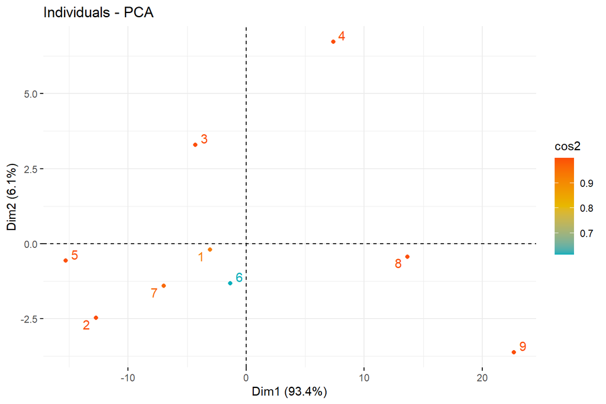

## Interpretación de un biplot

- La representación de las observaciones o los datos en un biplot equivale a proyectar las observaciones sobre el plano de las componentes principales estandarizadas para que tengan varianza unidad.
- La representación de variables mediante vectores de dos coordenadas cumple que la correlación entre dos variables iniciales \(\mathbf{X}_i\) y \(\mathbf{X}_j\) es aproximadamente el coseno del ángulo que forman en el biplot. Por tanto, si dos variables \(\mathbf{X}_i\) y \(\mathbf{X}_j\) están muy correlacionadas, el coseno será grande y el ángulo entre los vectores, pequeño. En caso contrario, si están poco correlacionadas, el coseno será pequeño y el ángulo entre los vectores estará próximo a un ángulo recto.

## Comunalidades.

En un ACP la comunalidad de la variable \(X_j\) retenida por las \(k\) primeras componentes es la proporción de varianza de la variable que queda explicada por esas componentes. Por ejemplo.

- Si retenemos sólo el componente \(CP_1\) la comunalidad de la variable \(X_j\) es:

\[h_j=r_{j 1}^2=\left( u_{1 j}\sqrt{\lambda_1}\right)^2\]

- Si retenemos los componentes\(CP_1\) y \(CP_2\) la comunalidad de la variable \(X_j\) es:

\[h_j=r_{j 1}^2+r_{2 j}^2=\left( u_{1 j}\sqrt{\lambda_1}\right)^2+ \left( u_{2 j}\sqrt{\lambda_2}\right)^2\]

## Interpretación de las variables y los individuos

## Interpretación de las variables y los individuos

- Las variables también pueden representar de forma simultanea con los individuos en los componentes principales.
- Esta representación se hace mediante las coordenadas que la matriz de componentes que nos explican las correlaciones de cada factor con cada variable.

## Circulo de correlación

- Cada variable está representada por el vector que une el origen de coordenadas cono el punto.
- Todos están en círculo unidad (círculo de correlación).
- A medida que cada variable se acerca a la circunferencia unidad está mejor representado por los componentes retenidas y viceversa.
- El ángulo entre variables y componentes nos da una idea de su correlación, al nivel de retención de varianza total que tengamos.
- Así variable perpendiculares tenderán a ser *incorreladas*.
- Los valores de una variable crecen en la dirección de ésta.

## Circulo de correlación

```r
factoextra::fviz_pca_var(solacp,
             col.var = "contrib",
             # Color por contribución asl pca
             gradient.cols = c("#00AFBB",
                               "#E7B800",
                               "#FC4E07"),
             repel = TRUE
             )
```

## Circulo de correlación

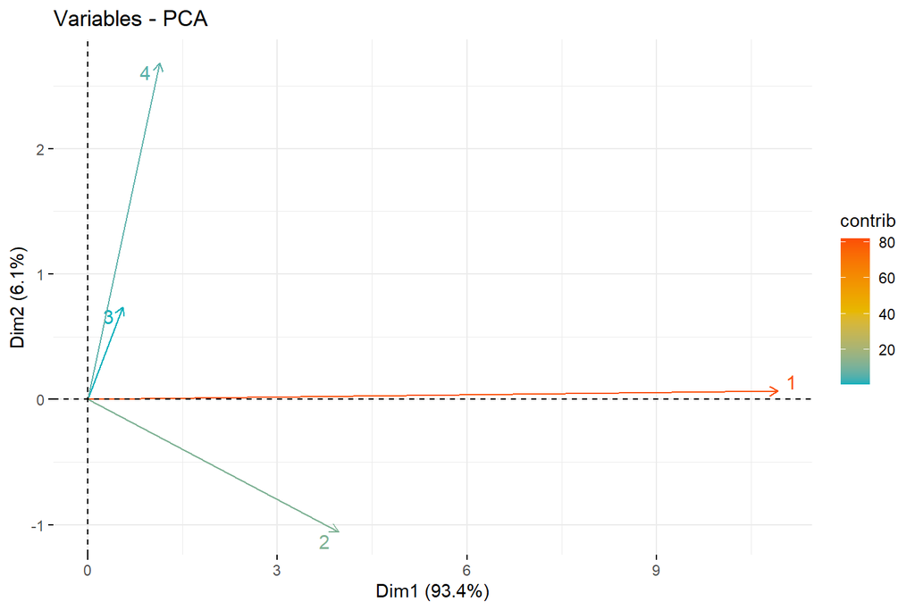

## Y muchas cosas más..

## Y muchas cosas más..

Para acabar…

- El Análisis factorial confirmatorio se realiza sobre modelos establecidos de factores y se hacen inferencias sobre sus propiedades.
- El análisis factorial descriptivo ayuda a la descripción de los datos y a la búsqueda de factores.
- Regresión Lineal Múltiple
- Clasificación.
- Análisis de correspondencias simples y múltiples.
- … y muchas otras más